# Peer review

This document is for the first Peer review assignment for the Coursera ‘Reproducible Research’ course.

It is made in RStudio and Knitted to HTML for review by classmates. In this document I use a stepcounter-data file, and analyse its ouput, as required.

The first task is loading in the CSV files:

```r
all_data <- read.csv ("activity.csv")
```

The first task is calculate the total number of steps per day, discarding any missing values. For this, I aggregate on the date, with the function sum, with discard of all NA’s (and then plot a histogram):

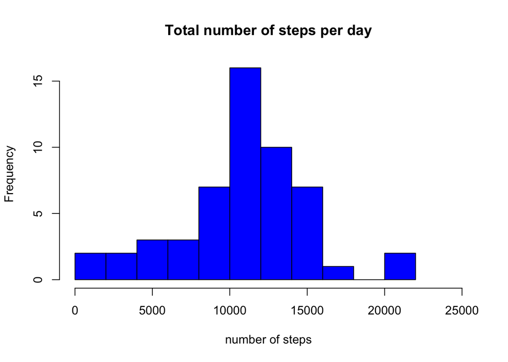

```r
aggregated_data <- aggregate(all_data$steps, by=list(all_data$date), FUN=sum)
#Make the histogram:
hist (aggregated_data$x,
      main = "Total number of steps per day",
      xlab = "number of steps",
      breaks = 10,
      col = "blue",
      xlim = c(0, 25000))
```

Next up is the calculation of the mean and median number of steps of all observations:

```r
mean_steps <- mean(aggregated_data$x, na.rm = TRUE)
median_steps <- median(aggregated_data$x, na.rm = TRUE)
mean_steps
```

```
## [1] 10766.19
```

```r
median_steps
```

```
## [1] 10765
```

Then, we’re zooming in on the daily pattern. For this, I draw a lineplot of the averages of the day. But first, aggregate on the intervals:

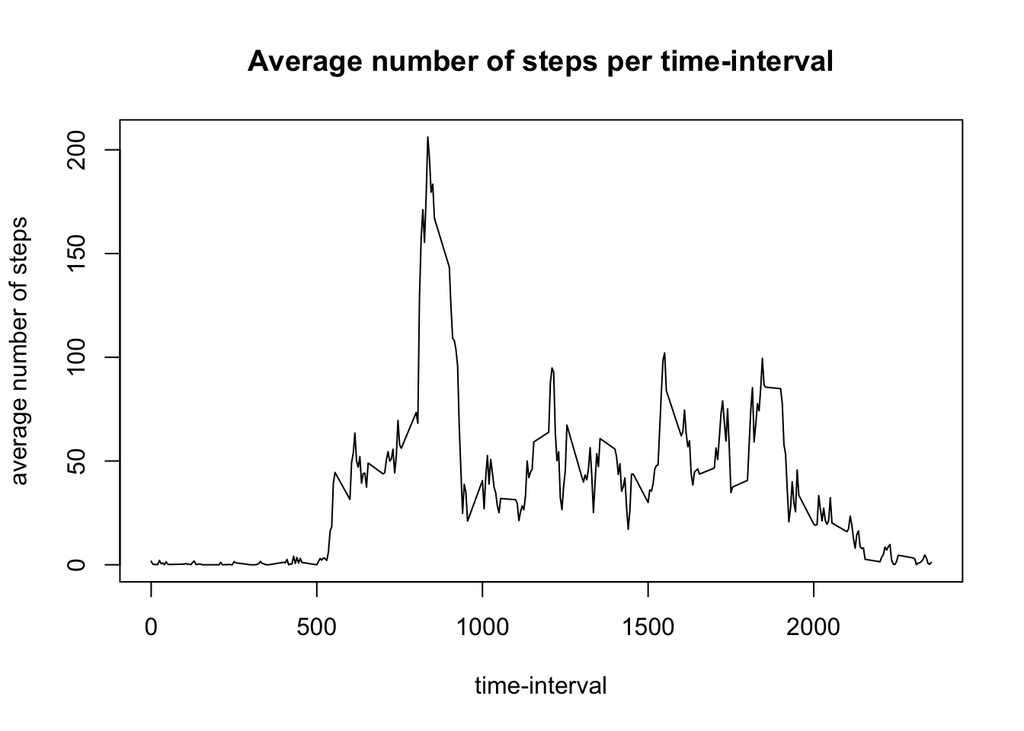

```r
aggregated_data2 <- aggregate(all_data$steps, by=list(Category=all_data$interval), FUN=mean, na.rm = TRUE)
#Make the plot:
plot (aggregated_data2$Category,
      aggregated_data2$x,
      main = "Average number of steps per time-interval",
      type = "l",
      xlab = "time-interval",
      ylab = "average number of steps")
```

Which time-interval is, on average, the one with the max number of steps?

```r
aggregated_data2$Category[which.max(aggregated_data2$x)]
```

```
## [1] 835
```

Let’s take a look at the missing values. How many are there?

```r
sum (is.na(all_data$steps))
```

```
## [1] 2304
```

Let’s try and fill that in. I fill them in on the averages of the intervals, based on the day-of-the-week. We have 60 days, so on average 8,5 ‘samples’ of each day o/t week. First, create a new dataset to contain all the data, and add a column for days-of-week.

```r
filled_in_data <- all_data
filled_in_data$day <- weekdays(as.Date(filled_in_data$date))
```

Create a temp set, with all means, based on weekday and interval. Because I don’t know exactly how many times I should calculate them, I do it in one go. It maybe slower, depending on the number of NA-intervals. But if I get it out of the way here, it’s more predictable.

```r
means_set <- temp_aggregate <- aggregate(filled_in_data$steps, by = list (filled_in_data$day, filled_in_data$interval), FUN = mean, na.rm = TRUE)
```

Then loop through the new setfilled_in_data, and if we find a missing observation, look up the means for that interval in the means_set.

```r
for (i in 1:nrow(all_data)) {
    if (is.na(filled_in_data$steps[i])) {
        #Copy the mean from the mean-set:
        temp_mean <- subset(means_set, means_set$Group.1 == filled_in_data$day[i] & means_set$Group.2 == filled_in_data$interval[i])
        #and put it in the filled-in set:
        filled_in_data$steps[i] = temp_mean$x
    }
}
```

Then, create a histogram from the filled-in set, through an aggregated set:

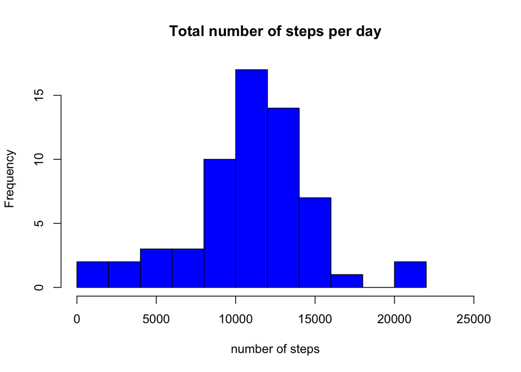

```r
aggregated_data <- aggregate(filled_in_data$steps, by=list(filled_in_data$date), FUN=sum)

hist (aggregated_data$x,
      main = "Total number of steps per day",
      xlab = "number of steps",
      breaks = 10,
      col = "blue",
      xlim = c(0, 25000))
```

Now, calculate the new mean and median, and then the difference:

```r
mean_steps_filledin <- mean(aggregated_data$x, na.rm = TRUE)
median_steps_filledin <- median(aggregated_data$x, na.rm = TRUE)
mean_steps_filledin
```

```
## [1] 10821.21
```

```r
median_steps_filledin
```

```
## [1] 11015
```

```r
mean_steps_filledin - mean_steps
```

```
## [1] 55.02092
```

```r
median_steps_filledin - median_steps
```

```
## [1] 250
```

Now, make a weekend/weekday factor variable (add to the filled_in_data):

```r
weekdaylist <- c('Monday', 'Tuesday', 'Wednesday', 'Thursday', 'Friday')
filled_in_data$WeekdayOrNot <- c('WeekendDay', 'Weekday')[(filled_in_data$day %in% weekdaylist)+1L]
```

Aggregate the data on week or weekend:

```r
aggregated_data <- aggregate(filled_in_data$steps, by=list(filled_in_data$interval, filled_in_data$WeekdayOrNot), FUN=mean)
```

And finally, put it into a panel plot

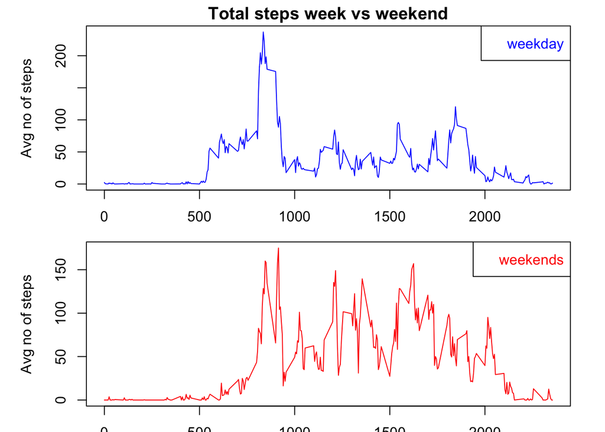

```r
par(mfrow = c(2,1), mar = c(1.5, 5, 1.5, 2))
with (aggregated_data[aggregated_data$Group.2 == "Weekday",], plot(Group.1, x, type = 'l', xlab = "Interval", col = "blue", ylab = "Avg no of steps", main="Total steps week vs weekend"))
legend ("topright", "weekday", text.col = "blue")
with (aggregated_data[aggregated_data$Group.2 == "WeekendDay",], plot(Group.1, x, type = 'l', xlab = "Interval", col = "red", ylab = "Avg no of steps"))
legend ("topright", "weekends", text.col = "red")
```